# Play resilience relationship across challenges

Sarah Ambruosi

2026-11-10

# 1 Packages

```r
# data management
library(tidyr)
library(dplyr)
library(tidyverse)
library(car)

# model fitting
library(lme4) # linear models
library(rptR) # repeatability assessment

# visualisation
library(ggplot2) # plots
library(patchwork) # combine plots
```

# 2 Repeatability assessment

For the repeatability assessment of play, the different play types were analysed in the form of counts of success and failure events (i.e., duration of time performing the behaviour versus not performing the behaviour). Play type includes individual locomotor play, social locomotor play, play-fight, object play, and total play as the sum f all four play types.

## 2.1 Data

```r
RPT_data_WUR <- read.csv("../data/WUR_behaviour_four_days.csv", sep=";")
RPT_data_WUR[,c(1:5)] <- lapply(RPT_data_WUR[,c(1:5)],as.factor)
RPT_data_WUR$LPS_Frus <- factor(RPT_data_WUR$LPS_Frus,levels = c("LPS", "Frus"))
RPT_data_WUR$Batch_Pen <- interaction(RPT_data_WUR$Batch, RPT_data_WUR$Pen) # variable to test pen repeatability

# Add total play
RPT_data_WUR$d_total_play <- RPT_data_WUR$d_locomotor_individual+RPT_data_WUR$d_locomotor_social+RPT_data_WUR$d_object_play+RPT_data_WUR$d_play_fight
RPT_data_WUR$fail_d_total_play <- 14400 - RPT_data_WUR$d_total_play

data <- RPT_data_WUR
summary(data)
```

```
##      Pig_ID    Batch  Pen    LPS_Frus      Day      d_locomotor_individual
##  100    :  4   3:64   2:64   LPS :128   Day_1:128   Min.   :   0.00
##  136    :  4   4:64   3:64   Frus:128   Day_2:128   1st Qu.:   5.79
##  343    :  4   5:64   8:64                          Median :  22.69
##  430    :  4   6:64   9:64                          Mean   :  48.79
##  708    :  4                                        3rd Qu.:  51.75
##  1037   :  4                                        Max.   :3024.36
##  (Other):232
##  d_locomotor_social  d_play_fight     d_object_play
##  Min.   :   0.00    Min.   :   0.00   Min.   :  0.00
##  1st Qu.:  65.28    1st Qu.:   0.00   1st Qu.:  0.00
##  Median : 135.46    Median :   8.44   Median : 12.02
##  Mean   : 212.90    Mean   :  25.53   Mean   : 30.57
##  3rd Qu.: 220.78    3rd Qu.:  28.41   3rd Qu.: 34.68
##  Max.   :6931.23    Max.   :1163.28   Max.   :507.67
##
##  fail_d_locomotor_individual fail_d_locomotor_social fail_d_play_fight
##  Min.   :11376               Min.   : 7469           Min.   :13237
##  1st Qu.:14348               1st Qu.:14179           1st Qu.:14372
##  Median :14377               Median :14265           Median :14392
##  Mean   :14351               Mean   :14187           Mean   :14374
##  3rd Qu.:14394               3rd Qu.:14335           3rd Qu.:14400
##  Max.   :14400               Max.   :14400           Max.   :14400
##
##  fail_d_object_play   Batch_Pen    d_total_play    fail_d_total_play
##  Min.   :13892      3.2    : 16   Min.   :   0.0   Min.   : 7469
##  1st Qu.:14365      4.2    : 16   1st Qu.: 111.9   1st Qu.:14047
##  Median :14388      5.2    : 16   Median : 203.0   Median :14197
##  Mean   :14369      6.2    : 16   Mean   : 317.8   Mean   :14082
##  3rd Qu.:14400      3.3    : 16   3rd Qu.: 353.0   3rd Qu.:14288
##  Max.   :14400      4.3    : 16   Max.   :6931.2   Max.   :14400
##                     (Other):160
```

```r
behaviours <- c("d_locomotor_individual", "d_locomotor_social", "d_object_play", "d_play_fight", "d_total_play")
```

**Metadata**:  
- *Pig_ID*: individual identification number of a pig.  
- *Batch*: batches included in this dataset [“3”, “4”, “5”, “6”].  
- *Pen*: identification number for each pen [“2”, “3”, “8”, “9”].  
- *Batch_Pen*: Interaction between batch and pen to assess pen-mevel repeatability.  
- *LPS_Frus*: Challenge to which the pig was submitted, either a lipopolysaccharide injection [“LPS”] or a social frustration challenge [“Frus”].  
- *Day*: the day of the observation either two days before the challenge [“1”] or the day before the challenge [“2”].

**Variables**:  
- *d_locomotor_individual, d_locomotor_social, d_play_fight, d_object_play, d_total_play*: duration performing the play type [0-14400s].  
- *fail_d_locomotor_individual fail_d_locomotor_social fail_d_play_fight fail_d_object_play, fail_d_total_play*: duration not performing the play type (total observation duration [14400s] minus duration of play type).

## 2.2 Play histograms

```r
play_by_pig <- RPT_data_WUR %>%
    group_by(Pig_ID, LPS_Frus, Day) %>%
    summarise(
        played = any(d_total_play > 0, na.rm = TRUE),
        .groups = "drop"
    )

# Proportions de porcs ayant joué ou non
summary_play <- play_by_pig %>%
    group_by(LPS_Frus, Day) %>%
    summarise(
        n_pigs = n(),
        n_played = sum(played),
        n_never_played = sum(!played),
        prop_played = n_played / n_pigs,
        prop_never_played = n_never_played / n_pigs,
        .groups = "drop"
    )

summary_play
```

```
## # A tibble: 4 × 7
##   LPS_Frus Day   n_pigs n_played n_never_played prop_played prop_never_played
##   <fct>    <fct>  <int>    <int>          <int>       <dbl>             <dbl>
## 1 LPS      Day_1     64       64              0       1                0
## 2 LPS      Day_2     64       62              2       0.969            0.0312
## 3 Frus     Day_1     64       61              3       0.953            0.0469
## 4 Frus     Day_2     64       63              1       0.984            0.0156
```

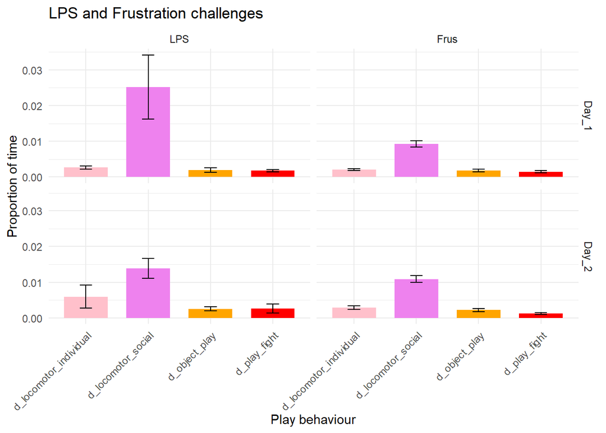

```r
data <- RPT_data_WUR %>%
  pivot_longer(
    cols = c(d_object_play, d_locomotor_individual, d_locomotor_social, d_play_fight),
    names_to = "Variable",
    values_to = "Duration"
  )

data <- data %>%
  group_by(LPS_Frus, Day, Variable) %>%
  summarise(
    mean = mean(Duration/14400, na.rm = TRUE),
    SEM = sd(Duration/14400, na.rm = TRUE) /
          sqrt(sum(!is.na(Duration/14400))),
    .groups = "drop"
  )

LPS_Frus_play <- ggplot(data,
             aes(x = Variable, y = mean, fill = Variable)) +
  geom_col(width = 0.7) +
  geom_errorbar(
    aes(ymin = mean - SEM,
        ymax = mean + SEM),
    width = 0.2,
    linewidth = 0.5
  ) +
  facet_grid(Day ~ LPS_Frus) +
  scale_fill_manual(values = c("pink", "violet", "orange", "red")) +
  labs(
    title = "LPS and Frustration challenges",
    x = "Play behaviour",
    y = "Proportion of time",
    fill = "Variable"
  ) +
  theme_minimal() +
  theme(
    axis.text.x = element_text(angle = 45, hjust = 1),
    legend.position = "none"
  )

LPS_Frus_play
```

```r
ggsave(
  "../plots/Fig1_Play_proportion_before_LPS_Frus.png",
  width = 12,
  height = 8,
  dpi = 500
)
```

## 2.3 Intra-LPS repeatability

### 2.3.1 Individual repeatability

Pig repeatability between day 1 and day 2 before LPS.

```r
data_LPS <- subset(RPT_data_WUR, LPS_Frus %in% "LPS")

rpt_LPS_prop <- lapply(behaviours, function(var) {

  formula <- as.formula(paste("cbind(", var, ",fail_", var, ") ~ (1 | Pig_ID)", sep = ""))

  rptProportion(formula, grname = c("Pig_ID"), data = data_LPS, nboot = 1000, npermut = 0)

})
```

```r
names(rpt_LPS_prop) <- c("individual locomotor play", "social locomotor play", "object play", "play-fight", "total play")

lapply(names(rpt_LPS_prop), function(var) {
  cat("Individual repeatability intra-LPS for", var, "\n")
  print(rpt_LPS_prop[[var]])
})
```

```
## Individual repeatability intra-LPS for individual locomotor play
##
##
## Repeatability estimation using the glmm method and logit link
##
## Repeatability for Pig_ID
## --------------------------------
## Link-scale approximation:
## R  = 0.014
## SE = 0.017
## CI = [0.007, 0.07]
## P  = 3.72e-06 [LRT]
##      NA [Permutation]
##
## Original-scale approximation:
## R  = 0.014
## SE = 0.017
## CI = [0.007, 0.07]
## P  = 3.72e-06 [LRT]
##      NA [Permutation]
##
## Individual repeatability intra-LPS for social locomotor play
##
##
## Repeatability estimation using the glmm method and logit link
##
## Repeatability for Pig_ID
## --------------------------------
## Link-scale approximation:
## R  = 0.014
## SE = 0.008
## CI = [0.002, 0.034]
## P  = 0.0189 [LRT]
##      NA [Permutation]
##
## Original-scale approximation:
## R  = 0.014
## SE = 0.008
## CI = [0.002, 0.034]
## P  = 0.0189 [LRT]
```

[output cut: 49 more lines]

```
## Repeatability for Pig_ID
## --------------------------------
## Link-scale approximation:
## R  = 0.008
## SE = 0.005
## CI = [0, 0.02]
## P  = 0.0676 [LRT]
##      NA [Permutation]
##
## Original-scale approximation:
## R  = 0.008
## SE = 0.005
## CI = [0, 0.02]
## P  = 0.0676 [LRT]
##      NA [Permutation]
```

### 2.3.2 Pen repeatability

Pen repeatability (i.e., a group of pig) between day 1 and day 2 before LPS.

```r
rpt_LPS_prop <- lapply(behaviours, function(var) {

  formula <- as.formula(paste("cbind(", var, ",fail_", var, ") ~ (1 | Batch_Pen)", sep = ""))

  rptProportion(formula, grname = c("Batch_Pen"), data = data_LPS, nboot = 1000, npermut = 0)

})
```

```r
names(rpt_LPS_prop) <- c("individual locomotor play", "social locomotor play", "object play", "play-fight", "total play")

lapply(names(rpt_LPS_prop), function(var) {
  cat("Pen-level repeatability intra-LPS for", var, "\n")
  print(rpt_LPS_prop[[var]])
})
```

```
## Pen-level repeatability intra-LPS for individual locomotor play
##
##
## Repeatability estimation using the glmm method and logit link
##
## Repeatability for Batch_Pen
## --------------------------------
## Link-scale approximation:
## R  = 0.006
## SE = 0.01
## CI = [0.001, 0.037]
## P  = 1.82e-05 [LRT]
##      NA [Permutation]
##
## Original-scale approximation:
## R  = 0.006
## SE = 0.01
## CI = [0.001, 0.037]
## P  = 1.82e-05 [LRT]
##      NA [Permutation]
##
## Pen-level repeatability intra-LPS for social locomotor play
##
##
## Repeatability estimation using the glmm method and logit link
##
## Repeatability for Batch_Pen
## --------------------------------
## Link-scale approximation:
## R  = 0.028
## SE = 0.023
## CI = [0.006, 0.096]
## P  = 1.09e-15 [LRT]
##      NA [Permutation]
##
## Original-scale approximation:
## R  = 0.028
## SE = 0.023
## CI = [0.006, 0.096]
## P  = 1.09e-15 [LRT]
```

[output cut: 49 more lines]

```
## Repeatability for Batch_Pen
## --------------------------------
## Link-scale approximation:
## R  = 0.015
## SE = 0.008
## CI = [0.003, 0.032]
## P  = 3.34e-08 [LRT]
##      NA [Permutation]
##
## Original-scale approximation:
## R  = 0.015
## SE = 0.008
## CI = [0.003, 0.032]
## P  = 3.34e-08 [LRT]
##      NA [Permutation]
```

## 2.4 Intra-frustration repeatability

### 2.4.1 Individual repeatability

```r
data_Frus <- subset(RPT_data_WUR, LPS_Frus %in% "Frus")


rpt_Frus_prop <- lapply(behaviours, function(var) {

  formula <- as.formula(paste("cbind(", var, ",fail_", var, ") ~ (1 | Pig_ID)", sep = ""))

  rptProportion(formula, grname = c("Pig_ID"), data = data_Frus, nboot = 1000, npermut = 0)

})
```

```r
names(rpt_Frus_prop) <- c("individual locomotor play", "social locomotor play", "object play", "play-fight", "total play")

lapply(names(rpt_Frus_prop), function(var) {
  cat("Individual repeatability intra-Frustration for", var, "\n")
  print(rpt_Frus_prop[[var]])
})
```

```
## Individual repeatability intra-Frustration for individual locomotor play
##
##
## Repeatability estimation using the glmm method and logit link
##
## Repeatability for Pig_ID
## --------------------------------
## Link-scale approximation:
## R  = 0.005
## SE = 0.004
## CI = [0.003, 0.02]
## P  = 2.96e-08 [LRT]
##      NA [Permutation]
##
## Original-scale approximation:
## R  = 0.005
## SE = 0.004
## CI = [0.003, 0.02]
## P  = 2.96e-08 [LRT]
##      NA [Permutation]
##
## Individual repeatability intra-Frustration for social locomotor play
##
##
## Repeatability estimation using the glmm method and logit link
##
## Repeatability for Pig_ID
## --------------------------------
## Link-scale approximation:
## R  = 0.007
## SE = 0.005
## CI = [0.003, 0.019]
## P  = 0.00129 [LRT]
##      NA [Permutation]
##
## Original-scale approximation:
## R  = 0.007
## SE = 0.005
## CI = [0.003, 0.019]
## P  = 0.00129 [LRT]
```

[output cut: 49 more lines]

```
## Repeatability for Pig_ID
## --------------------------------
## Link-scale approximation:
## R  = 0.011
## SE = 0.004
## CI = [0.006, 0.021]
## P  = 2.4e-08 [LRT]
##      NA [Permutation]
##
## Original-scale approximation:
## R  = 0.011
## SE = 0.004
## CI = [0.006, 0.021]
## P  = 2.4e-08 [LRT]
##      NA [Permutation]
```

### 2.4.2 Pen repeatability

```r
rpt_Frus_prop <- lapply(behaviours, function(var) {

  formula <- as.formula(paste("cbind(", var, ",fail_", var, ") ~ (1 | Batch_Pen)", sep = ""))

  rptProportion(formula, grname = c("Batch_Pen"), data = data_Frus, nboot = 1000, npermut = 0)

})
```

```r
names(rpt_Frus_prop) <- c("individual locomotor play", "social locomotor play", "object play", "play-fight", "total play")

lapply(names(rpt_Frus_prop), function(var) {
  cat("Pen-level repeatability intra-Frustration for", var, "\n")
  print(rpt_Frus_prop[[var]])
})
```

```
## Pen-level repeatability intra-Frustration for individual locomotor play
##
##
## Repeatability estimation using the glmm method and logit link
##
## Repeatability for Batch_Pen
## --------------------------------
## Link-scale approximation:
## R  = 0.001
## SE = 0.001
## CI = [0, 0.004]
## P  = 0.0484 [LRT]
##      NA [Permutation]
##
## Original-scale approximation:
## R  = 0.001
## SE = 0.001
## CI = [0, 0.004]
## P  = 0.0484 [LRT]
##      NA [Permutation]
##
## Pen-level repeatability intra-Frustration for social locomotor play
##
##
## Repeatability estimation using the glmm method and logit link
##
## Repeatability for Batch_Pen
## --------------------------------
## Link-scale approximation:
## R  = 0.001
## SE = 0.002
## CI = [0, 0.007]
## P  = 0.058 [LRT]
##      NA [Permutation]
##
## Original-scale approximation:
## R  = 0.001
## SE = 0.002
## CI = [0, 0.007]
## P  = 0.058 [LRT]
```

[output cut: 49 more lines]

```
## Repeatability for Batch_Pen
## --------------------------------
## Link-scale approximation:
## R  = 0.002
## SE = 0.002
## CI = [0, 0.006]
## P  = 0.0183 [LRT]
##      NA [Permutation]
##
## Original-scale approximation:
## R  = 0.002
## SE = 0.002
## CI = [0, 0.006]
## P  = 0.0183 [LRT]
##      NA [Permutation]
```

## 2.5 Global repeatability (challenge × day)

### 2.5.1 Individual repeatability

Repeatability adjusted for challenge, day, and their interaction.

```r
data <- RPT_data_WUR

rpt_Global_prop <- lapply(behaviours, function(var) {

  formula <- as.formula(paste("cbind(", var, ",fail_", var, ") ~ LPS_Frus*Day + (1 | Pig_ID)", sep = ""))

  rptProportion(formula, grname = c("Pig_ID"), data = data, nboot = 1000, npermut = 0)

})
```

```r
names(rpt_Global_prop) <- c("individual locomotor play", "social locomotor play", "object play", "play-fight", "total play")

lapply(names(rpt_Global_prop), function(var) {
  cat("Individual repeatability across day & challenge for", var, "\n")
  print(rpt_Global_prop[[var]])
})
```

```
## Individual repeatability across day & challenge for individual locomotor play
##
##
## Repeatability estimation using the glmm method and logit link
##
## Repeatability for Pig_ID
## --------------------------------
## Link-scale approximation:
## R  = 0.005
## SE = 0.004
## CI = [0.003, 0.02]
## P  = 2.82e-10 [LRT]
##      NA [Permutation]
##
## Original-scale approximation:
## R  = 0.005
## SE = 0.004
## CI = [0.003, 0.02]
## P  = 2.82e-10 [LRT]
##      NA [Permutation]
##
## Individual repeatability across day & challenge for social locomotor play
##
##
## Repeatability estimation using the glmm method and logit link
##
## Repeatability for Pig_ID
## --------------------------------
## Link-scale approximation:
## R  = 0.006
## SE = 0.003
## CI = [0.002, 0.014]
## P  = 0.00163 [LRT]
##      NA [Permutation]
##
## Original-scale approximation:
## R  = 0.006
## SE = 0.003
## CI = [0.002, 0.014]
## P  = 0.00163 [LRT]
```

[output cut: 49 more lines]

```
## Repeatability for Pig_ID
## --------------------------------
## Link-scale approximation:
## R  = 0.007
## SE = 0.003
## CI = [0.003, 0.013]
## P  = 1.28e-05 [LRT]
##      NA [Permutation]
##
## Original-scale approximation:
## R  = 0.007
## SE = 0.003
## CI = [0.003, 0.013]
## P  = 1.28e-05 [LRT]
##      NA [Permutation]
```

### 2.5.2 Pen repeatability

```r
rpt_Global_prop <- lapply(behaviours, function(var) {

  formula <- as.formula(paste("cbind(", var, ",fail_", var, ") ~ LPS_Frus*Day + (1 | Batch_Pen)", sep = ""))

  rptProportion(formula, grname = c("Batch_Pen"), data = data, nboot = 1000, npermut = 0)

})
```

```r
names(rpt_Global_prop) <- c("individual locomotor play", "social locomotor play", "object play", "play-fight", "total play")

lapply(names(rpt_Global_prop), function(var) {
  cat("Pen-level repeatability across day & challenge for", var, "\n")
  print(rpt_Global_prop[[var]])
})
```

```
## Pen-level repeatability across day & challenge for individual locomotor play
##
##
## Repeatability estimation using the glmm method and logit link
##
## Repeatability for Batch_Pen
## --------------------------------
## Link-scale approximation:
## R  = 0.002
## SE = 0.002
## CI = [0, 0.009]
## P  = 1.53e-05 [LRT]
##      NA [Permutation]
##
## Original-scale approximation:
## R  = 0.002
## SE = 0.002
## CI = [0, 0.009]
## P  = 1.53e-05 [LRT]
##      NA [Permutation]
##
## Pen-level repeatability across day & challenge for social locomotor play
##
##
## Repeatability estimation using the glmm method and logit link
##
## Repeatability for Batch_Pen
## --------------------------------
## Link-scale approximation:
## R  = 0.005
## SE = 0.004
## CI = [0.001, 0.015]
## P  = 3.49e-07 [LRT]
##      NA [Permutation]
##
## Original-scale approximation:
## R  = 0.005
## SE = 0.004
## CI = [0.001, 0.015]
## P  = 3.49e-07 [LRT]
```

[output cut: 49 more lines]

[output not shown]

# 3 Correlation analyses

## 3.1 WUR

### 3.1.1 LPS challenge

#### 3.1.1.1 Variable selection

```r
WUR_LPS <- read.csv("../data/WUR_LPS.csv", sep=";")

data <- WUR_LPS
data <- data %>%
  mutate(
    Pig_ID = as.factor(Pig_ID),
    Batch = as.factor(Batch),
    Pen = as.factor(Pen)
  )

# Define variables
behavior_vars <- c("p_total_play",  "p_object_play",    "p_locomotor_individual",   "p_locomotor_social",   "p_play_fight")
physio_vars <- c("Cortisol_Baseline", "Glucose_Baseline", "Lactate_Baseline", "Temperature_Baseline", "dROM_Baseline",   "Cortisol_Amplitude", "Glucose_Amplitude", "Lactate_Amplitude", "Temperature_Amplitude", "dROM_Amplitude", "ADG_38_45", "ADG_45_52")
```

**Metadata**:  
- *Pig_ID*: individual identification number of a pig.  
- *Batch*: batches included in this dataset [“3”, “4”, “5”, “6”].  
- *Pen*: identification number for each pen [“2”, “3”, “8”, “9”].

**Variables**:  
- *p_indplay, p_socplay, p_playfight, p_objplay, p_totalplay*: proportion of time performing the play type  
- *Cortisol*: plasma cortisol  
- *Glucose*: plasma glucose  
- *Lactate*: plasma D-lactate  
- *Temperature*: rectal temperature  
- *dROM*: derivatives of reactive oxygen metabolites  
- *ADG_38_45*: Average daily gain calculated between 38 and 45 days of age (before the LPS challenge)  
- *ADG_45_52*: Average daily gain calculated between 45 and 52 days of age (after the LPS challenge)  
- **Baseline** variables were measured just before the LPS challenge  
- **Amplitude** variables were calculated over the measurements at 1 hour, 3 hours and 5 hours after the challenge.

#### 3.1.1.2 Extract residuals

```r
residuals_dataset <- data.frame(Pig_ID = data$Pig_ID)

for (var in c(behavior_vars, physio_vars)) {
  #arcsine transformation for proportions of play, raw data for physiology
  x <- if (var %in% behavior_vars) asin(sqrt(data[[var]])) else data[[var]]
  residuals_dataset[[var]] <- residuals(
    lmer(x ~ 1 + (1 | Batch), data = data, na.action = na.exclude)
  )
}
```

#### 3.1.1.3 Correlations play-physio

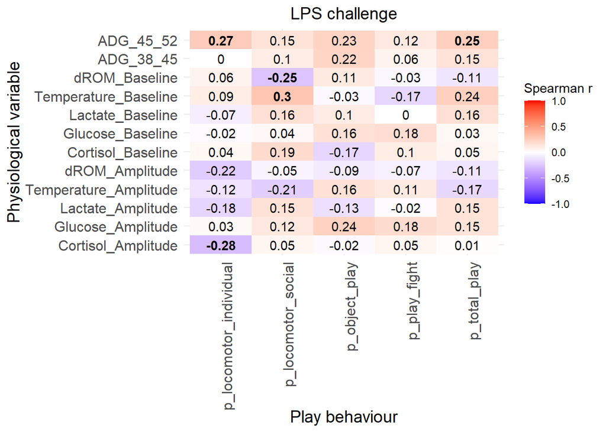

```r
results_df_LPS <- bind_rows(lapply(behavior_vars, function(b) {
  lapply(physio_vars, function(p) {

    test <- cor.test(
      residuals_dataset[[b]],
      residuals_dataset[[p]],
      method = "spearman",
      exact = FALSE
    )

    data.frame(
      behavior = b,
      physiology = p,
      correlation = unname(test$estimate),
      p_value = test$p.value
    )

  }) |> bind_rows()
})) %>%
  mutate(across(where(is.numeric), ~ round(.x, 4)))

heatmap_df <- results_df_LPS %>%
  mutate(
    sig = p_value < 0.05,
    physiology = factor(
      physiology,
      levels = c(
        unique(physiology[grepl("Amplitude", physiology)]),
        unique(physiology[grepl("Baseline", physiology)]),
        unique(physiology[grepl("ADG", physiology)])
      )
    )
  )

heatmap_LPS <- ggplot(heatmap_df, aes(y = physiology, x = behavior, fill = correlation)) +
  geom_tile() +
  geom_text(
    aes(label = round(correlation, 2),
        fontface = ifelse(sig, "bold", "plain"))
    ) +
  scale_fill_gradient2(
    low = "blue",
    mid = "white",
    high = "red",
    midpoint = 0,
    limits = c(-1, 1)
  ) +
  theme_minimal() +
  labs(
        title = "LPS challenge",
    x = "Play behaviour",
    y = "Physiological variable",
    fill = "Spearman r"
  )  +
theme(
  axis.text.x = element_text(size = 12, angle = 90, hjust = 1),
  axis.text.y = element_text(size = 12),
  axis.title.x = element_text(size = 14),
  axis.title.y = element_text(size = 14),
  plot.title = element_text(size = 14, hjust = 0.5)
)

heatmap_LPS
```

```r
ggsave(
  "../plots/Fig3-1_heatmap_LPS.png",
  width = 8,
  height = 7,
  dpi = 500
)
```

#### 3.1.1.4 Visualisation

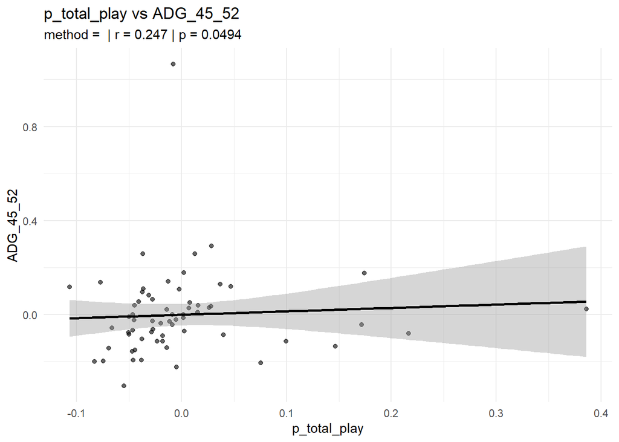

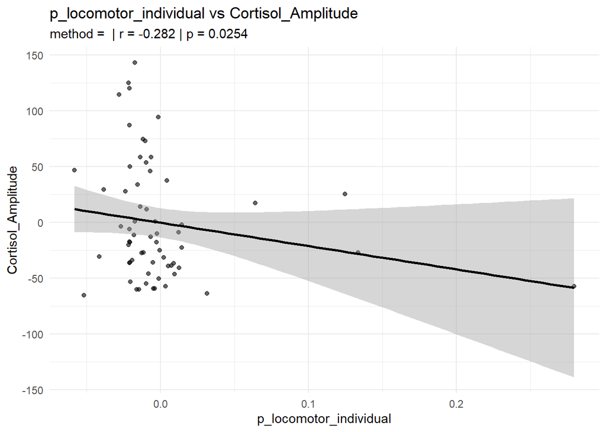

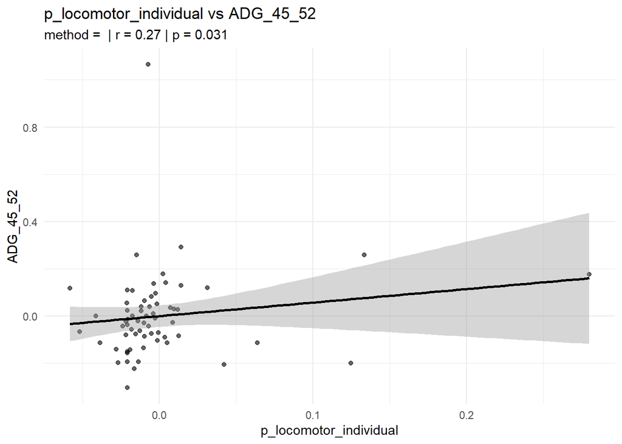

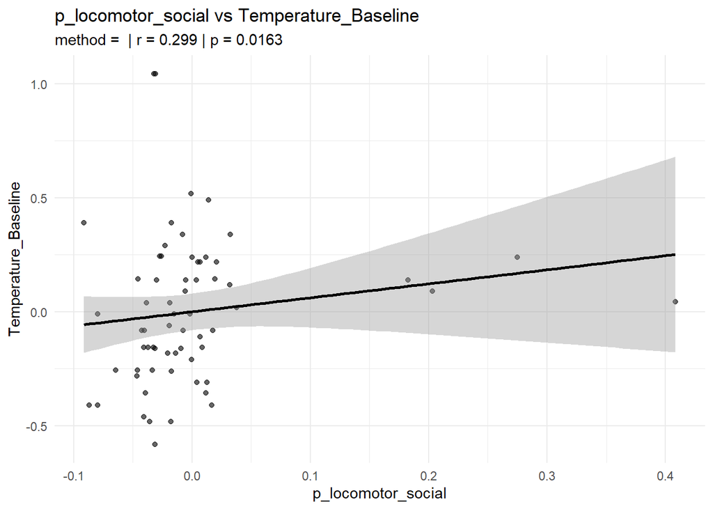

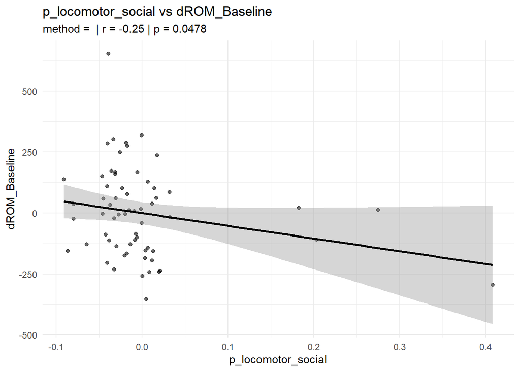

```r
# Filter significant results
sig_LPS <- results_df_LPS %>%
  filter(p_value < 0.05)

#Function for scatter plot
plot_corr <- function(data, xvar, yvar, r = NA, p = NA) {

  ggplot(data, aes(x = .data[[xvar]], y = .data[[yvar]])) +
    geom_point(alpha = 0.6) +
    geom_smooth(method = "lm", se = TRUE, color = "black") +
    theme_minimal() +
    labs(
      title = paste(xvar, "vs", yvar),
      subtitle = paste0(
        "method = ", sig_LPS$method[i],
        " | r = ", signif(r, 3),
        " | p = ", signif(p, 3)
        )
      )
}

plots_LPS <- list()

for(i in 1:nrow(sig_LPS)) {

  x <- sig_LPS$behavior[i]
  y <- sig_LPS$physiology[i]

  plots_LPS[[i]] <- plot_corr(
    residuals_dataset,
    xvar = x,
    yvar = y,
    r = sig_LPS$correlation[i],
    p = sig_LPS$p_value[i]
  )
}

for(p in plots_LPS) {
  print(p)
}
```

#### 3.1.1.5 Correlation within play

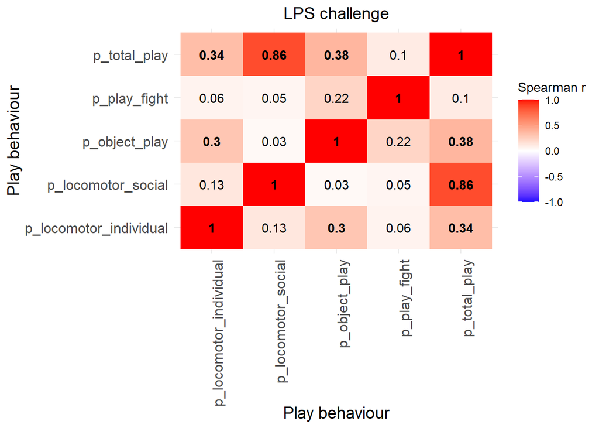

```r
results_df_LPS_play <- bind_rows(lapply(behavior_vars, function(b) {
  lapply(behavior_vars, function(p) {

    test <- cor.test(
      residuals_dataset[[b]],
      residuals_dataset[[p]],
      method = "spearman",
      exact = FALSE
    )

    data.frame(
      behavior1 = b,
      behavior2 = p,
      correlation = unname(test$estimate),
      p_value = test$p.value
    )

  })}) |> bind_rows()
) %>%
  mutate(across(where(is.numeric), ~ round(.x, 4)))

heatmap_df <- results_df_LPS_play %>%
  mutate(
    sig = p_value < 0.05
    )

heatmap_LPS_play <- ggplot(heatmap_df, aes(y = behavior1, x = behavior2, fill = correlation)) +
  geom_tile() +
  geom_text(
    aes(label = round(correlation, 2),
        fontface = ifelse(sig, "bold", "plain"))
    ) +
  scale_fill_gradient2(
    low = "blue",
    mid = "white",
    high = "red",
    midpoint = 0,
    limits = c(-1, 1)
  ) +
  theme_minimal() +
  labs(
        title = "LPS challenge",
    x = "Play behaviour",
    y = "Play behaviour",
    fill = "Spearman r"
  )  +
theme(
  axis.text.x = element_text(size = 12, angle = 90, hjust = 1),
  axis.text.y = element_text(size = 12),
  axis.title.x = element_text(size = 14),
  axis.title.y = element_text(size = 14),
  plot.title = element_text(size = 14, hjust = 0.5)
)

heatmap_LPS_play
```

```r
ggsave(
  "../plots/Supplementary_FigS2-1_heatmap_LPS_play.png",
  width = 8,
  height = 7,
  dpi = 500
)
```

#### 3.1.1.6 Correlation within physio

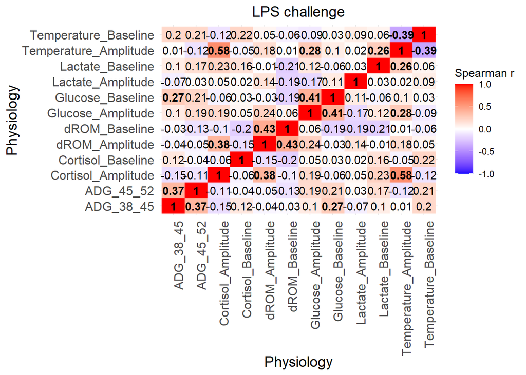

```r
results_df_LPS_physio <- bind_rows(lapply(physio_vars, function(b) {
  lapply(physio_vars, function(p) {

    test <- cor.test(
      residuals_dataset[[b]],
      residuals_dataset[[p]],
      method = "spearman",
      exact = FALSE
    )

    data.frame(
      physio1 = b,
      physio2 = p,
      correlation = unname(test$estimate),
      p_value = test$p.value
    )

  })}) |> bind_rows()
) %>%
  mutate(across(where(is.numeric), ~ round(.x, 4)))

heatmap_df <- results_df_LPS_physio %>%
  mutate(
    sig = p_value < 0.05
    )

heatmap_LPS_physio <- ggplot(heatmap_df, aes(y = physio1, x = physio2, fill = correlation)) +
  geom_tile() +
  geom_text(
    aes(label = round(correlation, 2),
        fontface = ifelse(sig, "bold", "plain"))
    ) +
  scale_fill_gradient2(
    low = "blue",
    mid = "white",
    high = "red",
    midpoint = 0,
    limits = c(-1, 1)
  ) +
  theme_minimal() +
  labs(
        title = "LPS challenge",
    x = "Physiology",
    y = "Physiology",
    fill = "Spearman r"
  )  +
theme(
  axis.text.x = element_text(size = 12, angle = 90, hjust = 1),
  axis.text.y = element_text(size = 12),
  axis.title.x = element_text(size = 14),
  axis.title.y = element_text(size = 14),
  plot.title = element_text(size = 14, hjust = 0.5)
)

heatmap_LPS_physio
```

```r
ggsave(
  "../plots/Supplementary_FigS2-2_heatmap_LPS_physio.png",
  width = 8,
  height = 7,
  dpi = 500
)
```

### 3.1.2 Frustration challenge

#### 3.1.2.1 Variable selection

```r
WUR_Frus <- read.csv("../data/WUR_Frustration.csv", sep=";")

data <- WUR_Frus
data <- data %>%
  mutate(
    Pig_ID = as.factor(Pig_ID),
    Batch = as.factor(Batch),
    Pen = as.factor(Pen)
  )

# Define variables
behavior_vars <- c("p_total_play",  "p_object_play",    "p_locomotor_individual",   "p_locomotor_social",   "p_play_fight")
physio_vars <- c("Cortisol_Baseline", "Glucose_Baseline", "Lactate_Baseline", "dROM_Baseline",   "Cortisol_Amplitude", "Glucose_Amplitude", "Lactate_Amplitude", "dROM_Amplitude", "ADG_45_52")
```

**Metadata**:  
- *Pig_ID*: individual identification number of a pig.  
- *Batch*: batches included in this dataset [“3”, “4”, “5”, “6”].  
- *Pen*: identification number for each pen [“2”, “3”, “8”, “9”].

#### 3.1.2.2 Extract residuals

```r
residuals_dataset <- data.frame(Pig_ID = data$Pig_ID)

for (var in c(behavior_vars, physio_vars)) {
  #arcsine transformation for proportions of play, raw data for physiology
  x <- if (var %in% behavior_vars) asin(sqrt(data[[var]])) else data[[var]]
  residuals_dataset[[var]] <- residuals(
    lmer(x ~ 1 + (1 | Batch), data = data, na.action = na.exclude)
  )
}
```

#### 3.1.2.3 Correlations play-physio

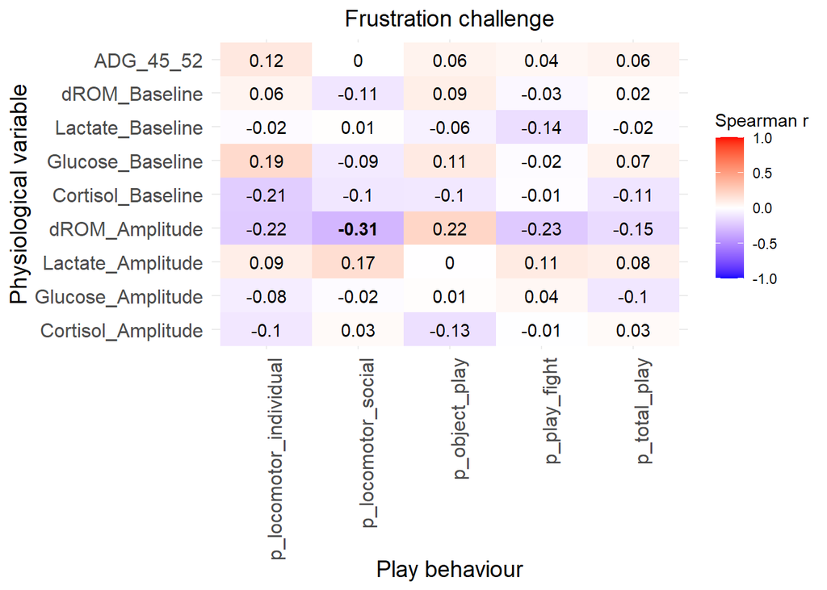

```r
results_df_Frus <- bind_rows(lapply(behavior_vars, function(b) {
  lapply(physio_vars, function(p) {

    test <- cor.test(
      residuals_dataset[[b]],
      residuals_dataset[[p]],
      method = "spearman",
      exact = FALSE
    )

    data.frame(
      behavior = b,
      physiology = p,
      correlation = unname(test$estimate),
      p_value = test$p.value
    )

  }) |> bind_rows()
})) %>%
  mutate(across(where(is.numeric), ~ round(.x, 4)))

heatmap_df <- results_df_Frus %>%
  mutate(
    sig = p_value < 0.05,
    physiology = factor(
      physiology,
      levels = c(
        unique(physiology[grepl("Amplitude", physiology)]),
        unique(physiology[grepl("Baseline", physiology)]),
        unique(physiology[grepl("ADG", physiology)])
      )
    )
  )

heatmap_Frus <- ggplot(heatmap_df, aes(y = physiology, x = behavior, fill = correlation)) +
  geom_tile() +
  geom_text(
    aes(label = round(correlation, 2),
        fontface = ifelse(sig, "bold", "plain"))
    ) +
  scale_fill_gradient2(
    low = "blue",
    mid = "white",
    high = "red",
    midpoint = 0,
    limits = c(-1, 1)
  ) +
  theme_minimal() +
  labs(
    title = "Frustration challenge",
    x = "Play behaviour",
    y = "Physiological variable",
    fill = "Spearman r"
  )  +
theme(
  axis.text.x = element_text(size = 12, angle = 90, hjust = 1),
  axis.text.y = element_text(size = 12),
  axis.title.x = element_text(size = 14),
  axis.title.y = element_text(size = 14),
  plot.title = element_text(size = 14, hjust = 0.5)
)

heatmap_Frus
```

```r
ggsave(
  "../plots/Fig3-2_heatmap_Frus.png",
  width = 8,
  height = 7,
  dpi = 500
)
```

#### 3.1.2.4 Visualisation

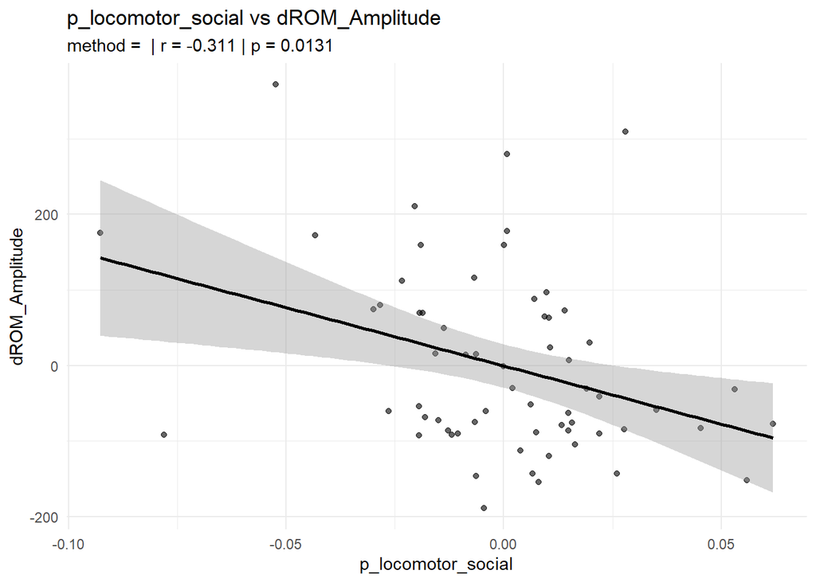

```r
# Filter significant results
sig_Frus <- results_df_Frus %>%
  filter(p_value < 0.05)

#Function for scatter plot
plot_corr <- function(data, xvar, yvar, r = NA, p = NA) {

  ggplot(data, aes(x = .data[[xvar]], y = .data[[yvar]])) +
    geom_point(alpha = 0.6) +
    geom_smooth(method = "lm", se = TRUE, color = "black") +
    theme_minimal() +
    labs(
      title = paste(xvar, "vs", yvar),
      subtitle = paste0(
        "method = ", sig_Frus$method[i],
        " | r = ", signif(r, 3),
        " | p = ", signif(p, 3)
        )
      )
}

plots_Frus <- list()

for(i in 1:nrow(sig_Frus)) {

  x <- sig_Frus$behavior[i]
  y <- sig_Frus$physiology[i]

  plots_Frus[[i]] <- plot_corr(
    residuals_dataset,
    xvar = x,
    yvar = y,
    r = sig_Frus$correlation[i],
    p = sig_Frus$p_value[i]
  )
}

for(p in plots_Frus) {
  print(p)
}
```

#### 3.1.2.5 Correlation within play

```r
results_df_Frus_play <- bind_rows(lapply(behavior_vars, function(b) {
  lapply(behavior_vars, function(p) {

    test <- cor.test(
      residuals_dataset[[b]],
      residuals_dataset[[p]],
      method = "spearman",
      exact = FALSE
    )

    data.frame(
      behavior1 = b,
      behavior2 = p,
      correlation = unname(test$estimate),
      p_value = test$p.value
    )

  })}) |> bind_rows()
) %>%
  mutate(across(where(is.numeric), ~ round(.x, 4)))

heatmap_df <- results_df_Frus_play %>%
  mutate(
    sig = p_value < 0.05
    )

heatmap_Frus_play <- ggplot(heatmap_df, aes(y = behavior1, x = behavior2, fill = correlation)) +
  geom_tile() +
  geom_text(
    aes(label = round(correlation, 2),
        fontface = ifelse(sig, "bold", "plain"))
    ) +
  scale_fill_gradient2(
    low = "blue",
    mid = "white",
    high = "red",
    midpoint = 0,
    limits = c(-1, 1)
  ) +
  theme_minimal() +
  labs(
        title = "Frustration challenge",
    x = "Play behaviour",
    y = "Play behaviour",
    fill = "Spearman r"
  )  +
theme(
  axis.text.x = element_text(size = 12, angle = 90, hjust = 1),
  axis.text.y = element_text(size = 12),
  axis.title.x = element_text(size = 14),
  axis.title.y = element_text(size = 14),
  plot.title = element_text(size = 14, hjust = 0.5)
)

ggsave(
  "../plots/Supplementary_FigS2-3_heatmap_Frus_play.png",
  width = 8,
  height = 7,
  dpi = 500
)
```

[output not shown]

#### 3.1.2.6 Correlation within physio

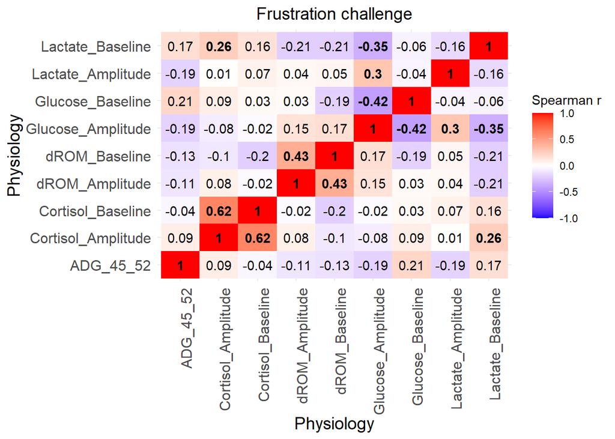

```r
results_df_Frus_physio <- bind_rows(lapply(physio_vars, function(b) {
  lapply(physio_vars, function(p) {

    test <- cor.test(
      residuals_dataset[[b]],
      residuals_dataset[[p]],
      method = "spearman",
      exact = FALSE
    )

    data.frame(
      physio1 = b,
      physio2 = p,
      correlation = unname(test$estimate),
      p_value = test$p.value
    )

  })}) |> bind_rows()
) %>%
  mutate(across(where(is.numeric), ~ round(.x, 4)))

heatmap_df <- results_df_Frus_physio %>%
  mutate(
    sig = p_value < 0.05
    )

heatmap_Frus_physio <- ggplot(heatmap_df, aes(y = physio1, x = physio2, fill = correlation)) +
  geom_tile() +
  geom_text(
    aes(label = round(correlation, 2),
        fontface = ifelse(sig, "bold", "plain"))
    ) +
  scale_fill_gradient2(
    low = "blue",
    mid = "white",
    high = "red",
    midpoint = 0,
    limits = c(-1, 1)
  ) +
  theme_minimal() +
  labs(
        title = "Frustration challenge",
    x = "Physiology",
    y = "Physiology",
    fill = "Spearman r"
  )  +
theme(
  axis.text.x = element_text(size = 12, angle = 90, hjust = 1),
  axis.text.y = element_text(size = 12),
  axis.title.x = element_text(size = 14),
  axis.title.y = element_text(size = 14),
  plot.title = element_text(size = 14, hjust = 0.5)
)

heatmap_Frus_physio
```

```r
ggsave(
  "../plots/Supplementary_FigS2-4_heatmap_Frus_physio.png",
  width = 8,
  height = 7,
  dpi = 500
)
```

## 3.2 ANSES

### 3.2.1 Play histograms

```r
ANSES <- read.csv("../data/ANSES.csv", sep=";")

# Define variables
behavior_vars <- c("p_total_play",  "p_enrichment", "p_locomotor_individual",   "p_locomotor_social",   "p_play_fight")
physio_vars <- c("cortisol_Baseline", "Glucose_Baseline", "Lactate_Baseline", "Temperature_Baseline", "DROM_Baseline", "FRAP_Baseline", "NEFA_Baseline",  "Granulo_lymphocyte_ratio_Baseline",  "Haptoglobin_Baseline", "NB_monocyte_Baseline","cortisol_Amplitude", "Glucose_Amplitude", "Lactate_Amplitude", "Temperature_Amplitude", "DROM_Amplitude", "FRAP_Amplitude", "NEFA_Amplitude",  "Granulo_lymphocyte_ratio_Amplitude",    "Haptoglobin_Amplitude",    "NB_monocyte_Amplitude","ADG_baseline", "ADG_D0_D9")

play_by_pig <- ANSES %>%
    group_by(Pig_ID, Inoculation, Housing) %>%
    summarise(
        played = any(p_total_play-p_enrichment > 0, na.rm = TRUE),
        .groups = "drop"
    )

# Proportions de porcs ayant joué ou non
summary_play <- play_by_pig %>%
    group_by(Inoculation, Housing) %>%
    summarise(
        n_pigs = n(),
        n_played = sum(played),
        n_never_played = sum(!played),
        prop_played = n_played / n_pigs,
        prop_never_played = n_never_played / n_pigs,
        .groups = "drop"
    )

summary_play
```

```
## # A tibble: 4 × 7
##   Inoculation Housing n_pigs n_played n_never_played prop_played
##   <chr>       <chr>    <int>    <int>          <int>       <dbl>
## 1 control     ENR         15       15              0       1
## 2 control     MiN         15       15              0       1
## 3 inoc        ENR         15       14              1       0.933
## 4 inoc        MiN         15       15              0       1
## # ℹ 1 more variable: prop_never_played <dbl>
```

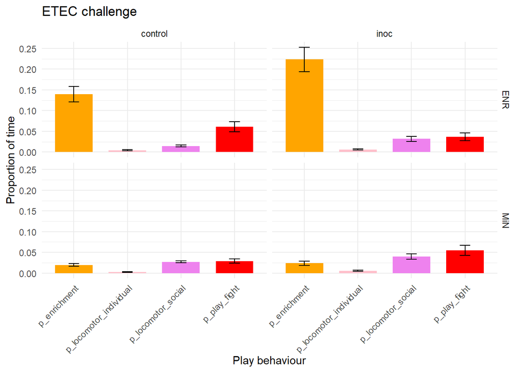

```r
data <- ANSES %>%
  pivot_longer(
    cols = c(p_enrichment, p_locomotor_individual, p_locomotor_social, p_play_fight),
    names_to = "Variable",
    values_to = "Proportion"
  )

data <- data %>%
  group_by(Housing, Inoculation, Variable) %>%
  summarise(
    mean = mean(Proportion, na.rm = TRUE),
    SEM = sd(Proportion, na.rm = TRUE) /
          sqrt(sum(!is.na(Proportion))),
    .groups = "drop"
  )

ETEC_play <- ggplot(data,
             aes(x = Variable, y = mean, fill = Variable)) +
  geom_col(width = 0.7) +
  geom_errorbar(
    aes(ymin = mean - SEM,
        ymax = mean + SEM),
    width = 0.2,
    linewidth = 0.5
  ) +
  facet_grid(Housing ~ Inoculation) +
  scale_fill_manual(values = c("orange", "pink", "violet", "red")) +
  labs(
    title = "ETEC challenge",
    x = "Play behaviour",
    y = "Proportion of time",
    fill = "Variable"
  ) +
  theme_minimal() +
  theme(
    axis.text.x = element_text(angle = 45, hjust = 1),
    legend.position = "none"
  )

ETEC_play
```

```r
ggsave(
  "../plots/Fig2_Play_proportion_before_ETEC.png",
  width = 12,
  height = 8,
  dpi = 500
)
```